# Section 7.4: NP-Complete Languages

# Polynomial-time Reductions

## Recall: Mapping reducibility

Let $A$ and $B$ be languages over an alphabet $\Sigma$. We say that $A$ is *mapping reducible* to $B$, written $A \leq_\text{m} B$, if there is a computable function (i.e., a *reduction*) $f:\Sigma^\ast \longrightarrow \Sigma^\ast$ such that, for every $w \in \Sigma^\ast$,
$$w \in A \Longleftrightarrow f(w) \in B$$

## Polynomial-time Reduction

If $f$ is a mapping reduction $A \leq_\text{m} B$ and $f$ runs in polynomial time, then we say that $A$ is *polynomial time reducible* to $B$, written $A \leq_\text{P} B$.

- If $A \leq_\text{P} B$ and $B \in \text{P}$, then $A \in \text{P}$.
- Informally $A \leq_\text{P} B$ means that $B$ is “harder” than $A$ (or at least as hard).

## $\mathit{3SAT}$

A *3cnf-formula* is a Boolean formula of the form
$$(a_1 \vee b_1 \vee c_1) \wedge (a_2 \vee b_2 \vee c_2) \wedge \cdots
\wedge (a_k \vee b_k \vee c_k)$$

- Notice: such a formula is true exactly when each triple has at least one true variable.
- $\mathit{3SAT} = \{\langle \phi \rangle \mid \phi \text{ is a satisfiable 3cnf-formula} \}$.

## $\mathit{3SAT} \leq_\text{P} \mathit{CLIQUE}$

A reduction function $f$ from $\mathit{3SAT}$ to $\mathit{CLIQUE}$ has to *input* a formula
$$\phi = (a_1 \vee b_1 \vee c_1) \wedge (a_2 \vee b_2 \vee c_2) \wedge
\cdots \wedge (a_k \vee b_k \vee c_k)$$
and *output* a graph $f(\phi)$, such that $\langle \phi \rangle \in \mathit{3SAT}$ iff $\langle f(\phi), k \rangle \in \textit{CLIQUE}$.

- If we had such a function, we could decide $\textit{3SAT}$ by deciding $\textit{CLIQUE}$.
- As long as this function runs in polynomial time, then if $\textit{CLIQUE} \in \text{P}$, then $\textit{3SAT} \in \text{P}$.

## Reduction function

Given a formula $\phi = (a_1 \vee b_1 \vee c_1) \wedge (a_2 \vee b_2 \vee c_2) \wedge \cdots \wedge (a_k \vee b_k \vee c_k)$, the vertices of the graph $f(\phi)$ are the variables, and the edges connect any two variables (in different triples) that do not contradict each other.

- A $k$-clique in this graph would be a set of $k$ variables that do not contradict each other.
- Set all of these to 1, and you have satisfied $\phi$.
- If so such $k$-clique exists, there is no way to make all the triples true.

## Example

The formula $(x_1 \vee x_1 \vee x_2) \wedge (\overline{x_1} \vee \overline{x_2} \vee \overline {x_2}) \wedge (\overline{x_1}\vee x_2 \vee x_2)$ maps to the following graph.

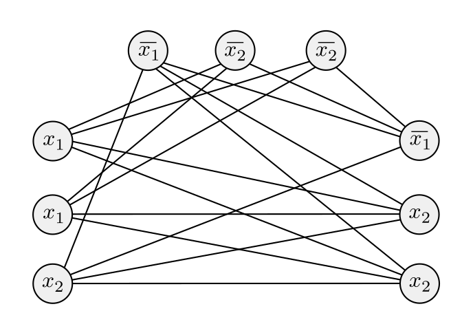

# The hardest problem in $\text{NP}$

## Any $\text{NP}$ problem reduces to $\mathit{SAT}$

**Theorem.** Let $A \in \text{NP}$. Then $A \leq_\text{P} \mathit{SAT}$.

- $\mathit{SAT}$ is the “hardest” problem in $\text{NP}$.
- A solver for $\mathit{SAT}$ can be used to solve any problem in $\text{NP}$.
- If $\mathit{SAT} \in \text{P}$, then $\text{P} = \text{NP}$.

*Proof idea:*

- If $A \in \text{NP}$, then there is a NTM $M$ that decides $A$.
- Convert $M$ to a formula such that satisfying the formula would reveal an accepting branch in the computation tree of $M$.
  - Check that this conversion is polynomial time.

## computation branch $\rightarrow$ tableau

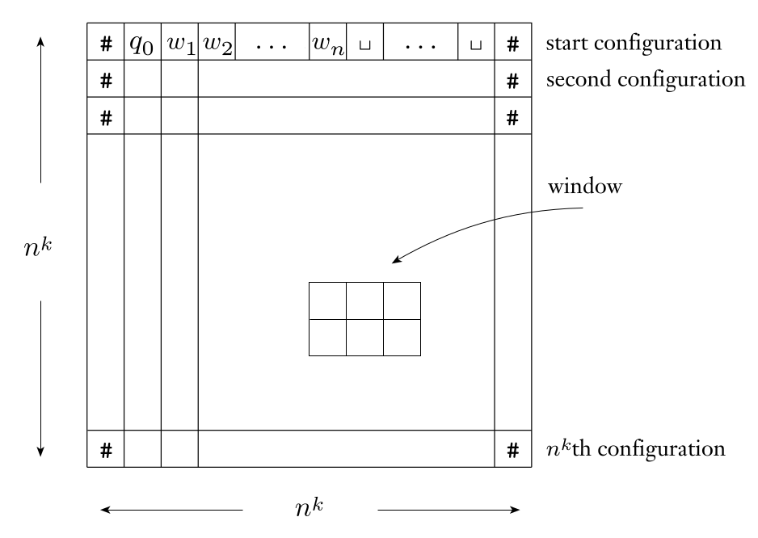

Need to construct a formula such that satisfying it would reveal a *legal* and *accepting* branch of the NTM (i.e., tableau).

## Constructing the formula

Variables: $x_{i,j,s}$, where $(i,j)$ are tableau coordinates and $s$ is a symbol or state. Then $\phi = \phi_\text{cell} \wedge \phi_\text{start} \wedge \phi_\text{move} \wedge \phi_\text{accept}$, where

- $\phi_\text{cell}$ is satisfied if only one $x_{i,j,s}$ is true for each cell.
- $\phi_\text{start}$ is satisfied if the first row if a legal start.
- $\phi_\text{move}$ is satisfied if all the windows are legal.
- $\phi_\text{accept}$ is satisfied if the last row is an accept state.

Can build $\phi$ in polynomial time.

# $\text{NP}$-complete languages

## The class of $\text{NP}$-complete languages

A language $A \in \text{NP}$ is called *$\text{NP}$-complete* if solving $A$ in polynomial time would solve any problem in $\text{NP}$ in polynomial time.

- $\mathit{SAT}$ is $\text{NP}$-complete.
- $\mathit{3SAT}$ is $\text{NP}$-complete. (can modify tableau proof)
- $\mathit{CLIQUE}$ is $\text{NP}$-complete (because $\mathit{3SAT} \leq_\text{P} \mathit{CLIQUE}$)

Informally, the $\text{NP}$-complete languages represent the hardest problems in $\text{NP}$. It is unknown whether any is in $\text{P}$, but if any is ever found, then $\text{P} = \text{NP}$. ([Lots of problems](https://en.wikipedia.org/wiki/List_of_NP-complete_problems) are known to be $\text{NP}$-complete.)

## Showing that a language is $\text{NP}$-complete

To show that a language $A$ is $\text{NP}$-complete, you must:

- Show that $A \in \text{NP}$. (it’s not too hard)
- Show that $L \leq_\text{P} A$ for some $\text{NP}$-complete language $L$. (it’s “harder” than some other $\text{NP}$-complete language)

If you only know the second thing, then $A$ is called *$\text{NP}$-hard*.